# Model Performance

## Contribution of Module Eigengenes

#### Do MEs Improve Model Performance?

```r
ME_comparison <- resamples(list(Clinical = CF_logistic_model, ME = ME_logistic_model, Full = full_logistic_model))

summary(ME_comparison)
```

```
##
## Call:
## summary.resamples(object = ME_comparison)
##
## Models: Clinical, ME, Full
## Number of resamples: 25
##
## ROC
##               Min.   1st Qu.    Median      Mean   3rd Qu.      Max. NA's
## Clinical 0.5445269 0.6938776 0.7433712 0.7461464 0.8024119 0.8849722    0
## ME       0.5965909 0.6771800 0.7384045 0.7475665 0.7940631 0.9183673    0
## Full     0.5928030 0.6883117 0.7087199 0.7365878 0.7840909 0.9239332    0
##
## Sens
##                Min.   1st Qu.    Median      Mean    3rd Qu.      Max. NA's
## Clinical 0.00000000 0.0000000 0.0000000 0.0530303 0.09090909 0.1818182    0
## ME       0.09090909 0.1818182 0.1818182 0.2557576 0.36363636 0.5000000    0
## Full     0.00000000 0.1818182 0.2727273 0.2706061 0.33333333 0.5454545    0
##
## Spec
##               Min.   1st Qu.    Median      Mean   3rd Qu.      Max. NA's
## Clinical 0.8775510 0.9795918 1.0000000 0.9811735 1.0000000 1.0000000    0
## ME       0.8775510 0.9183673 0.9387755 0.9369558 0.9591837 1.0000000    0
## Full     0.8163265 0.8775510 0.9183673 0.9139796 0.9387755 0.9795918    0
```

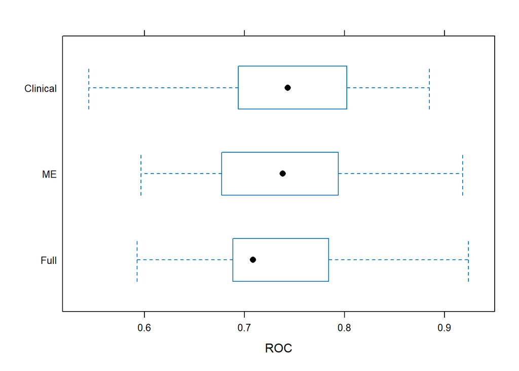

```r
bwplot(ME_comparison, metric = "ROC")
```

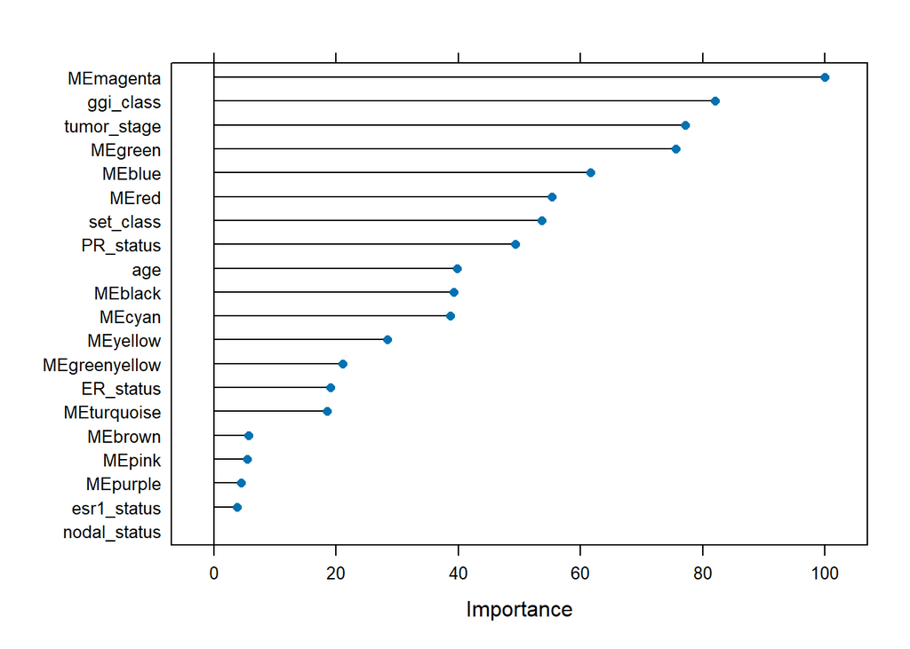

```r
plot(varImp(full_logistic_model))
```

The summary shows some improvement in sensitivity for models including module eigengenes and thus a coresponding decrease in specificity. In general, the results show that including module eigengenes don’t significantly improve ROC, sensitivity or specificity (for the logistic regression models). However, predictor importance shows that some module eigengenes are more important than some clinical factors, indicating the importance of including genetic data through networks analysis for predicting chemotherapy response. These results could be compared to using differential abundance of individual genes to show whether conducting a networks analysis significantly improves models using genetic data.